# mTEC development analysis

Kristen Wells

May 29, 2019

This is a document that can be used to reproduce all analysis from the (eventual paper). While all steps are included, some steps take a long time and it is faster to just load in the provided R object.

If you would like to skip the data processing and just make figures from pre-made objects, go here

All analysis depends on loading the mTEC.10x.pipeline r package

```r
library(mTEC.10x.pipeline)
```

## Loading in the data

*In the Snakemake pipeline, this correponds to rule seurat_object and runs the script create_seurat.R*

All data is provided in the form of empty R Seurat objects that were made by running the command

```r
mtec_data <- Seurat::Read10X(data.dir = sequence_dir)
mtec <- CreateSeuratObject(raw.data = mtec_data, min.cells = 3, min.genes = 200,
  project = project_name)
```

where “sequence_dir” is the path to the output of cellranger count and project_name = “RankL_ablation”

## Aire trace processing

*In the Snakemake pipeline, this correponds to rule final_analysis and runs the script analysis_driver.R found in the aireTrace/scripts directory*

This is the processing that was done to create the aireTrace Seurat object. If you would rather skip this processing, skip to figures section.

load in necessary packages

```r
library(Seurat)
library(dplyr)
library(scran)
library(DDRTree)
```

load in empty aireTrace object and gene lists

```r
# Change this to load from the mtec.10x.data package
load("/home/kwells4/mTEC_dev/mtec_snakemake/aireTrace/analysis_outs/seurat_aireTrace_empty.rda")
data_dir <- "/home/kwells4/mTEC_dev/data/"
load(paste0(data_dir, "TFs.rda"))
load(paste0(data_dir, "gene_to_ensembl.rda"))
```

Set plotting colors

```r
stage_color_df <- data.frame("Cortico_medullary" = "#CC6600",
                             "Ccl21a_high" = "#009933",
                             "Early_Aire" = "#0066CC",
                             "Aire_positive" = "#660099",
                             "Late_Aire" = "#FF0000",
                             "Tuft" = "#990000",
                             "unknown" = "#666666")

stage_color <- t(stage_color_df)[ , 1]

stage_levels <- c("Cortico_medullary", "Ccl21a_high", "Early_Aire",
                  "Aire_positive", "Late_Aire", "Tuft", "unknown")
```

Initial processing. This is run through the mTEC.10x.pipeline package, but combines the initial processing steps recommended by Seurat

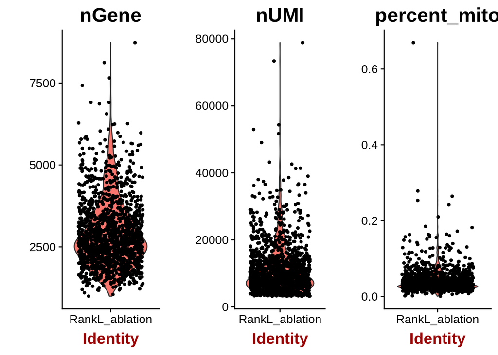

```r
# Add mitochondiral percent to the meta data
mtec <- add_perc_mito(mtec)

# Plot quality plots
qc_plot(mtec)
```

```r
# remove low quality cells, normalize and scale data, find variable genes, and perform PCA
mtec <- process_cells(mtec)
```

```
## Scaling data matrix
```

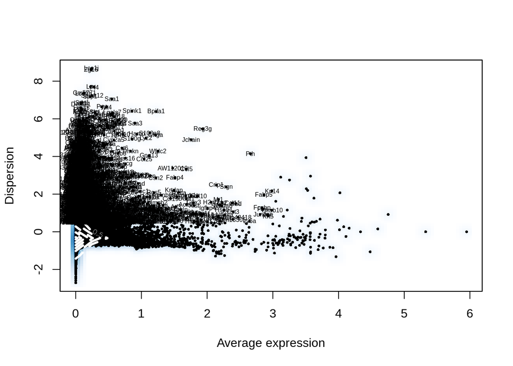

```
## [1] "PC1"
## [1] "Krt5"   "Igfbp4" "Gsn"    "Krt14"  "Gas1"
## [1] ""
## [1] "Cyba"  "Cldn7" "Cd52"  "Cox17" "Csn2"
## [1] ""
## [1] ""
## [1] "PC2"
## [1] "Srgn"    "S100a16" "Ubd"     "Aire"    "S100a14"
## [1] ""
## [1] "Rgs13"   "Ly6g6f"  "Alox5ap" "Lrmp"    "Avil"
## [1] ""
## [1] ""
## [1] "PC3"
## [1] "Spink5"   "Pdzk1ip1" "Oit1"     "Lypd3"    "Gsta4"
## [1] ""
## [1] "Tmsb10" "Vim"    "Phgdh"  "Top2a"  "Birc5"
## [1] ""
## [1] ""
## [1] "PC4"
## [1] "Selplg"  "Samsn1"  "Zmynd15" "Ccr7"    "Cytip"
## [1] ""
## [1] "Gm13305" "S100a16" "Il11ra1" "Fezf2"   "Lrrc42"
## [1] ""
## [1] ""
## [1] "PC5"
## [1] "Birc5"  "Ccna2"  "Cdca8"  "Nusap1" "Stmn1"
## [1] ""
## [1] "Mia"    "Sparc"  "Stkld1" "Mgp"    "Gpx3"
## [1] ""
## [1] ""
```

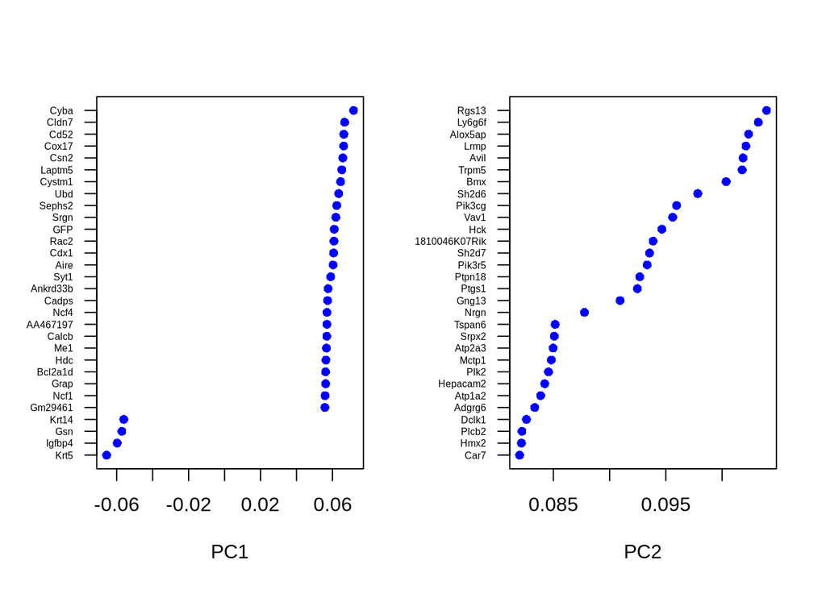

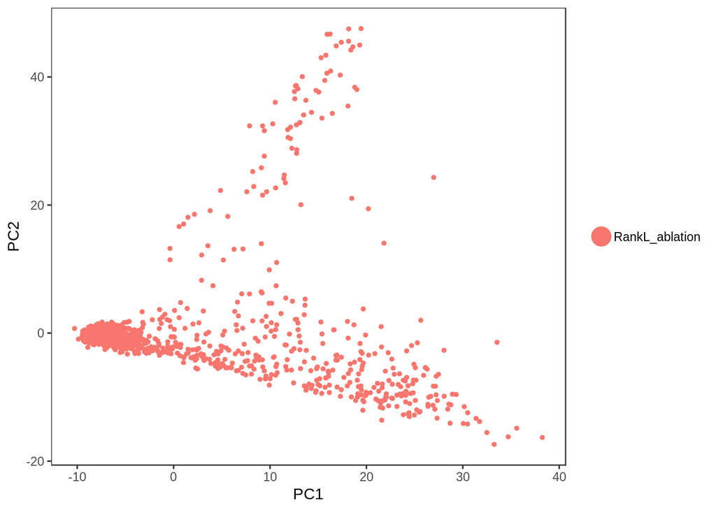

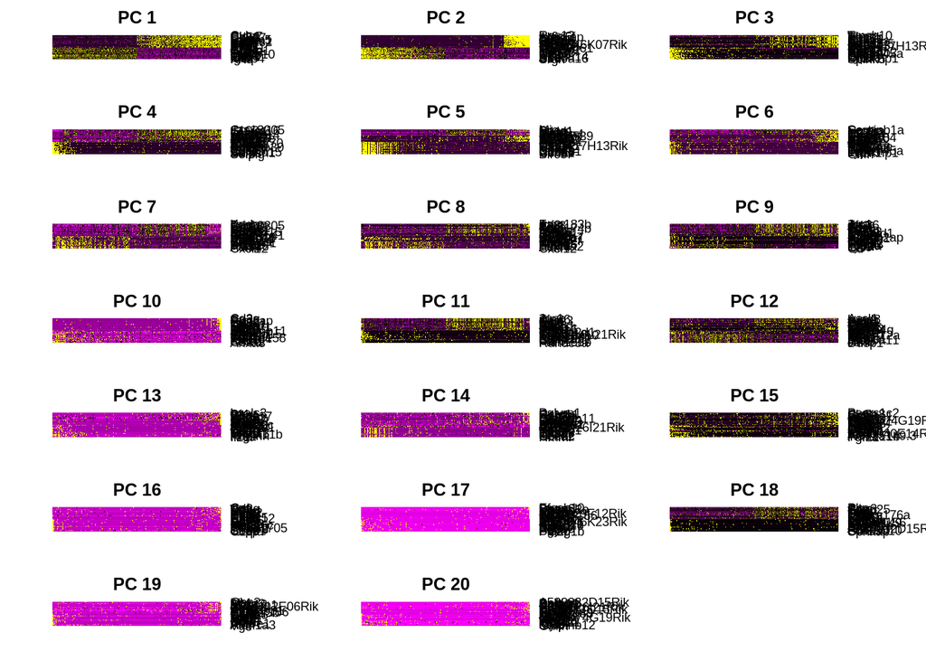

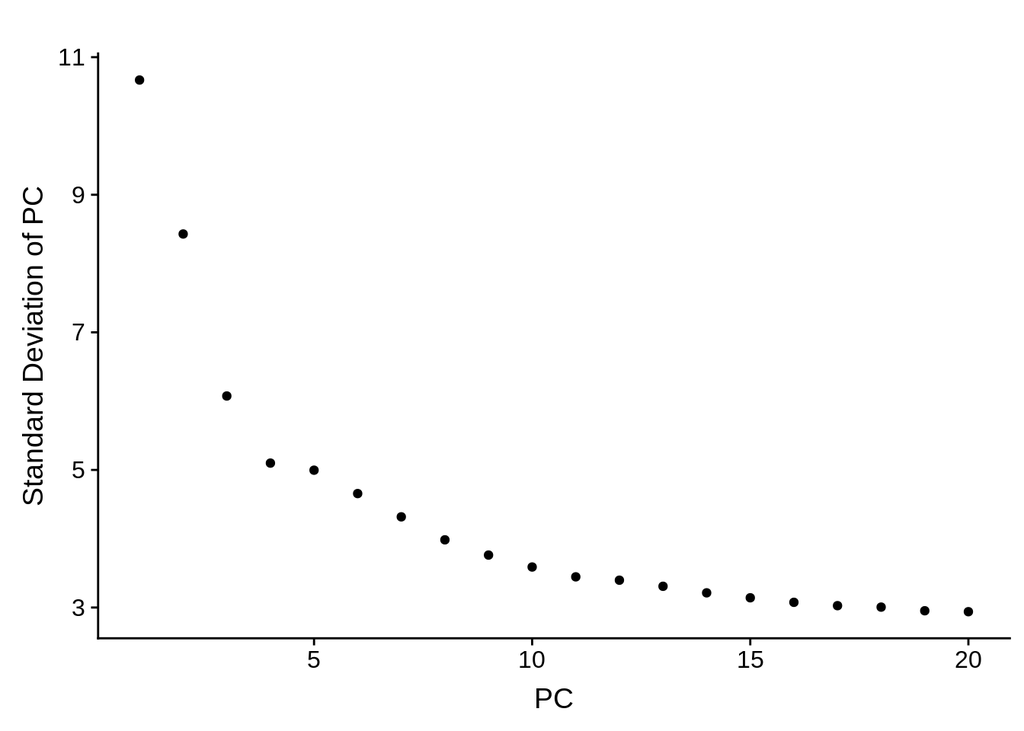

```r
# Plot a PCA and determine dimensions to use by looking at heatmaps and elbow plots
PC_plots(mtec, jackstraw = FALSE, test_pcs = 1:20)
```

If running on a cluster and if you have the time, you can make a jackstraw plot to test the number of PCs to keep. Run using:

```r
PC_plots(mtec, jackstraw = TRUE, test_pcs = 1:20)
```

After determining the number of PCs to use from the PC_plots outputs, clustering and dimensional reduction can be performed using the appropriate number of PCs. Here, we used the first 12 PCs.

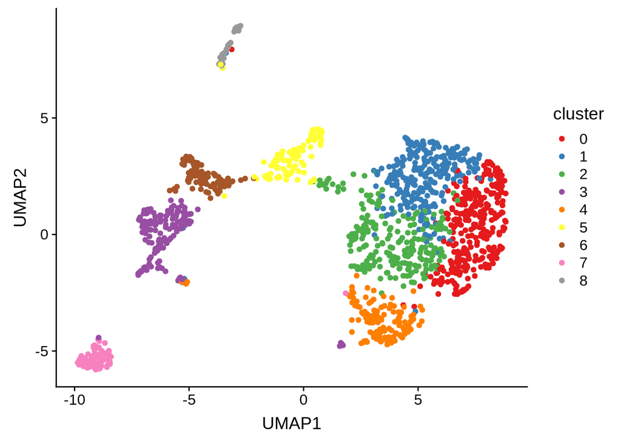

```r
# Decide PCs based on output of jackstraw plot
mtec <- group_cells(mtec, dims_use = 1:12)

plot <- tSNE_PCA(mtec, "cluster")
```

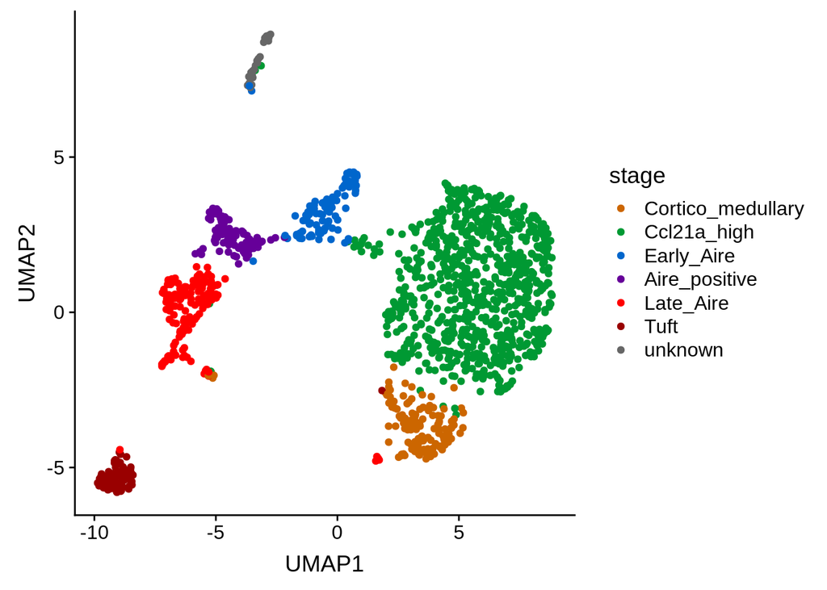

```r
# Name clusters (these were determined originally based on gene expression)
stage_list <- c("0" = "Ccl21a_high", "1" = "Ccl21a_high", "2" = "Ccl21a_high",
                "3" = "Late_Aire", "4" = "Cortico_medullary",
                "5" = "Early_Aire", "6" = "Aire_positive",
                "7" = "Tuft", "8" = "unknown")

mtec <- set_stage(mtec, stage_list)

mtec@meta.data$stage <- factor(mtec@meta.data$stage,
                               levels = stage_levels)

plot_2 <- tSNE_PCA(mtec, "stage", color = stage_color)
```

## Making the paper figures

figures

If you haven’t followed the steps outlined above to pre-process the data and would just like to make figures using the final seurat objects, run this command

```r
# Change this to load from mTEC.10x.data
load("/home/kwells4/mTEC_dev/mtec_snakemake/aireTrace/analysis_outs/seurat_aireTrace.rda")
```